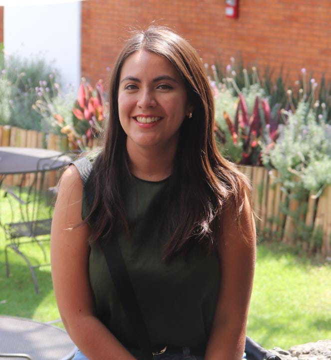

# María J. Palma Martínez

## 👋🏼 About me

I am a Ph.D. student in the Biomedical Sciences Program at the National Autonomous University of Mexico (UNAM), working at the Center for Genomic Sciences. During my master’s, I had the incredible opportunity to work on the Mexican Biobank (MXBiobank) project.

Currently, my research focuses on promoting intentional decisions regarding how we group humans in genetics and biomedical research. As part of this effort, a transdisciplinary team of collaborators and I developed a computational pipeline and [web browser](http://sohaillab.ccg.unam.mx/gg-nc/) based on relational thinking.

I am a bioinformatician at heart, but I am also deeply interested in the study of non-human species. I truly believe in the power of science to uncover knowledge that allows us to make better decisions as a society.

## 🎓 Education

**National Autonomous University of Mexico (UNAM)** | Cuernavaca, Mexico *Ph.D. in Biomedical Sciences* | January 2022 - Present

**LANGEBIO, Cinvestav** | Irapuato, Mexico *M.Sc. in Integrative Biology* | September 2019 - January 2022

**National Autonomous University of Mexico (UNAM)** | Cuernavaca, Mexico *B.S. in Genomic Sciences* | August 2015 - June 2019

## 🔬 Professional Experience

**Graduate Researcher**

- **PhD Degree:** Population structure analysis such as PCA, Fst, Admixture, GRM, IBD estimation, and community detection in genetic networks.
- **Master’s Degree:** Quality control for genetic datasets, uniparental haplogroups determination, phylogenetic networks, and sex-biased analysis based on ancestry estimated on the X-chromosome and the autosomes.

## 🌍 Other Research Experience

- **Summer Research** (2019) | *Department of Genetics, Leicester University, UK*. Advisor: Mark A. Jobling, Ph.D. Y chromosome haplogroups determination and Haplogroup networks in the Mexican Biobank.
- **Research Assistant** (2018) | *Program of Genomic Ecology, Center for Genomic Sciences, UNAM*. Advisor: Esperanza Martínez Romero, Ph.D. Bioinformatics and molecular biology techniques.
- **Summer Research** (2017) | *National Laboratory of Genomics for Biodiversity (LANGEBIO) - Cinvestav Irapuato*. Advisor: Andrés Moreno Estrada, Ph.D. Population genetics analysis.
- **Internship** (2016) | *Department of Molecular Cell Biology, University of California Merced*. Advisor: Emilia Huerta-Sánchez, Ph.D. Population genetics analysis.
- **Summer Research** (2016) | *International Research Laboratory on the Human Genome (LIIGH), UNAM*. Advisor: María Ávila Arcos, Ph.D. Mitochondrial haplogroups determination for Afromexican individuals.
- **Winter Research** (2015) | *Cinvestav Unidad Irapuato*. Advisor: Gabriela Olmedo Álvarez, Ph.D. Molecular biology techniques.
- **Internship** (2014) | *Department of Biology, University of Guanajuato*. Advisor: Roberto Zazueta Sandoval, Ph.D. Detection of dihydrodioldehydrogenase involved in the degradation of aromatic hydrocarbons.

## 👩🏻‍🏫 Teaching

- **Teaching Assistant & Invited Lecturer** (2024) | Introduction to Bioinformatics, Genomic Sciences undergraduate program, UNAM.
- **Instructor of Record** (2021) | Chemistry and Chemistry lab at Escuela de Nivel Medio Superior de Irapuato, Guanajuato University.
- **Teaching Assistant** (2019, 2021) | Advanced bioinformatics workshop, UNAM.
- **Teaching Assistant** (2017) | Biochemistry course, Genomic Sciences undergraduate program, UNAM.

## 💻 Software Development

- **Software Developer** (2019) | Software development for mitochondrial haplogroups determination. Company: *SOMOS Ancestry*.

## 📚 Publications

1. Palma-Martínez, M. J., Posadas-García, Y. S., Shaukat, A., López-Ángeles, B. E., & Sohail, M. (2025). [Evolution, genetic diversity, and health](https://doi.org/10.1038/s41591-025-03558-1). *Nature Medicine*, 1-11.
2. Palma-Martínez, M. J., Posadas-García, Y. S., López-Ángeles, B. E., Quiroz-López, C., Lewis, A. C., Bird, K. A., … Sohail, M. (2024). [The multi-scale complexity of human genetic variation beyond continental groups](https://doi.org/10.1101/2024.12.11.627824). *bioRxiv*, 2024-12.
3. Sohail, M., Palma-Martínez, M.J., Chong, A.Y., … Moreno-Estrada, A. (2023). [Mexican Biobank advances population and medical genomics of diverse ancestries](https://doi.org/10.1038/s41586-023-06560-0). *Nature*, 622, 775–783.
4. Jiménez-Kaufmann, A., Chong, A. Y., Cortés, A., Quinto-Cortés, C. D., Fernandez-Valverde, S. L., Ferreyra-Reyes, L., Cruz-Hervert, L., Medina-Muñoz, S., Sohail, M., Palma-Martinez, M. J., … Moreno-Estrada, A. (2021). [Imputation Performance in Latin American Populations: Improving Rare Variants Representation With the Inclusion of Native American Genomes](https://doi.org/10.3389/fgene.2021.719791). *Frontiers in Genetics*, 12, 719791.
5. Ranz, J. M., González, P. M., Clifton, B. D., Nazario-Yepiz, N. O., Hernández-Cervantes, P. L., Palma-Martínez, M. J., … Abreu-Goodger, C. (2021). [A de novo transcriptional atlas in Danaus plexippus reveals variability in dosage compensation across tissues](https://doi.org/10.1038/s42003-021-02335-3). *Communications Biology*, 4(1), 1-13.

## 🏆 Achievements & Awards

- **Graduate Student Excellence Award** (2024) | *SMBE (Society for Molecular Biology and Evolution)*. Awarded to 10 PhD students across SMBE.
- **Registration Only Award** (2020) | *SMBE*. [Canceled due to the COVID-19 pandemic].
- **Gabino Barreda Medal for University Merit** (2019) | *UNAM*. Honor awarded to the student with the highest grade-point average in their college graduating class, Genomic Sciences Bachelor’s Program.
- **PAECI Scholarship** (2016) | *UNAM*. Merit-based scholarship that funds an international internship. Internship conducted at the Huerta-Sanchez Lab, UC Merced.
- **Science Olympiad Excellence Scholarship** (2015-2019) | *Mexican Academy of Sciences*. Scholarship awarded to undergraduate students with high rankings at the National Sciences Olympiads.

## 🪴 Interests and Hobbies

- 🏋️‍♀️ **Exercise:** I am into going to the gym and running.
- 🍳 **Cooking:** I love preparing food and trying new recipes.
- 🐈 **Cats:** I am a huge cat lover!